# data_exploration

```r
# Load each dataset

# Air pollution (no2, nox, pm2.5, pm10, and absorbances)
env=read.csv("../data/airpollution.csv")
# Olink proteomics data for SOD1, SOD2, and IL-6
prot=read.csv("../data//env_prot_expressions.csv")
# Clinical and demographic data for UK Biobank participants
pheno=read.csv("../data/phenotype_data.csv")
```

```r
# For clarity I am changing the "s" column name to "participant_id"
names(env)[names(env) == "s"] <- "participant_id"
names(prot)[names(prot) == "s"] <- "participant_id"
names(pheno)[names(pheno) == "s"] <- "participant_id"

# Check to see that it worked
colnames(env)
colnames(prot)
colnames(pheno)
```

1. 'participant_id'

2. 'no2'

3. 'nox'

4. 'pm10_2010'

5. 'pm25_2010'

6. 'pm25absorbance_2010'

7. 'pm25_10_2010'

1. 'sod1_rint'

2. 'sod2_rint'

3. 'il6_rint'

4. 'participant_id'

1. 'participant_id'

2. 'disease'

3. 'sex'

4. 'age'

5. 'waist_circumference'

6. 'coffee_intake'

7. 'pulse_rate'

8. 'EKG_heart_rate'

9. 'ventricular_rate'

10. 'trunk_fat_volume'

11. 'tobacco_smoking'

12. 'age_stopped_smoking'

13. 'weight'

14. 'body_fat_percent'

15. 'BMI'

# **Air pollution data**

```r
dim(env)
```

1. 502242

2. 7

```r
# Define the columns to check for missingness
pollution_vars <- c("no2", "nox", "pm10_2010", "pm25_2010", "pm25absorbance_2010", "pm25_10_2010")

# Count how many of those variables are NA for each participant
env$missing_pollution_count <- rowSums(is.na(env[, pollution_vars]))

# Summary of missing patterns
table(env$missing_pollution_count)

# Check how many people are missing all 6 pollution variables
sum(env$missing_pollution_count == 6)
```

```
     0      4      6
460951  33916   7375
```

7375

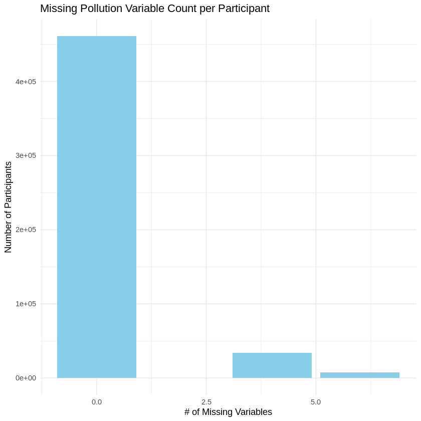

```r
library(ggplot2)

ggplot(env, aes(x = missing_pollution_count)) +
  geom_bar(fill = "skyblue") +
  labs(title = "Missing Pollution Variable Count per Participant",
       x = "# of Missing Variables", y = "Number of Participants") +
  theme_minimal()
```

```r
# Drop rows with participants missing all pollution variables
env_clean <- env[env$missing_pollution_count < 6, ]
dim(env_clean)
```

1. 494867

2. 8

```r
# Check ranges of pollution variables to ensure that they fit within a realistic range
# Ranges are defined on Dataset exploration document

summary(env_clean[, pollution_vars])
```

```
      no2              nox           pm10_2010       pm25_2010
 Min.   : 12.93   Min.   : 19.74   Min.   :11.78   Min.   : 8.17
 1st Qu.: 21.48   1st Qu.: 34.41   1st Qu.:15.25   1st Qu.: 9.29
 Median : 26.25   Median : 42.43   Median :16.03   Median : 9.93
 Mean   : 26.71   Mean   : 44.11   Mean   :16.24   Mean   : 9.99
 3rd Qu.: 31.26   3rd Qu.: 50.79   3rd Qu.:17.01   3rd Qu.:10.57
 Max.   :108.49   Max.   :265.94   Max.   :31.39   Max.   :21.31
                                   NA's   :33916   NA's   :33916
 pm25absorbance_2010  pm25_10_2010
 Min.   :0.83        Min.   : 5.57
 1st Qu.:1.00        1st Qu.: 5.84
 Median :1.13        Median : 6.11
 Mean   :1.19        Mean   : 6.43
 3rd Qu.:1.30        3rd Qu.: 6.64
 Max.   :4.60        Max.   :12.82
 NA's   :33916       NA's   :33916
```

Looks like most of our missing values are all from the PM data which accounts for 33,916 participants. For these participants we will only be able to run analysis on no2 and nox if running all variables independently.

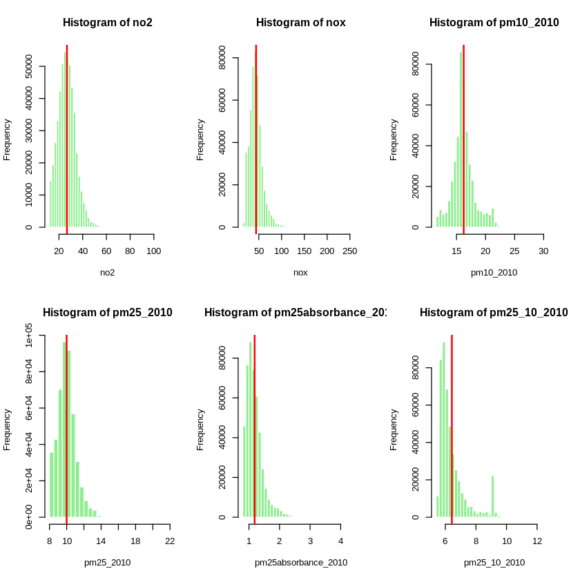

```r
# Plot distributions of each variable
# Set up plotting area (2 rows x 3 columns)
par(mfrow = c(2, 3))

# Plot histograms for each pollution variable
for (var in pollution_vars) {
  hist(env_clean[[var]],
       main = paste("Histogram of", var),
       xlab = var,
       col = "lightgreen",
       border = "white",
       breaks = 40)
       abline(v = mean(env_clean[[var]], na.rm = TRUE), col = "red", lwd = 2) #abline at the mean
}
```

```r
# Check for any duplicate participant IDs
any(duplicated(env_clean$participant_id))
```

FALSE

# Environmental Protein Expression Data

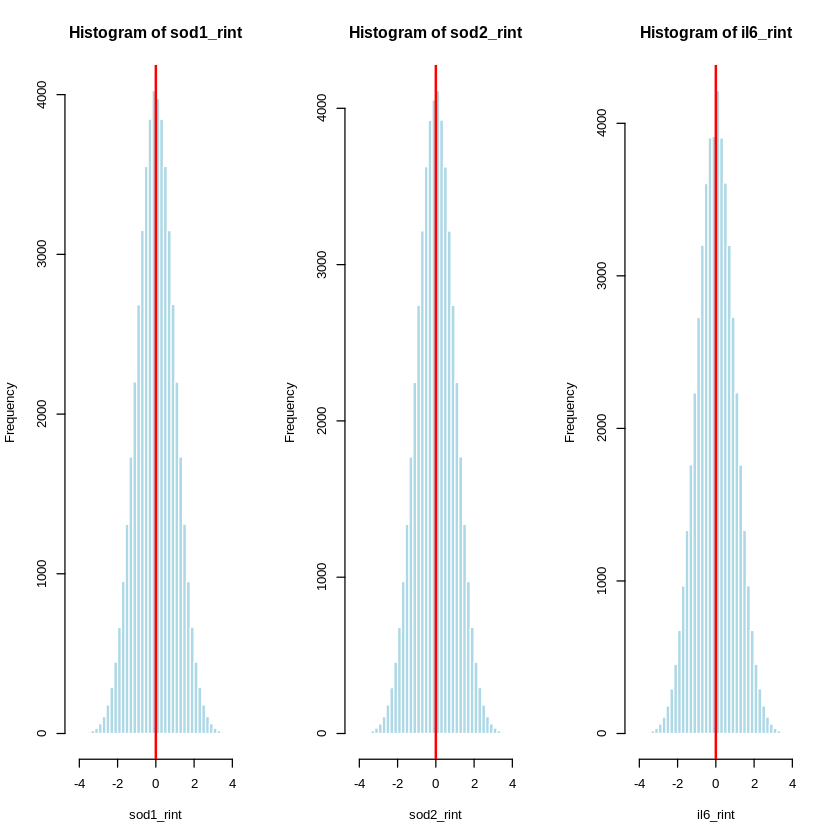

```r
# Plot distributions of each protein
par(mfrow = c(1, 3))

# List of protein columns
protein_vars <- c("sod1_rint", "sod2_rint", "il6_rint")

# Loop to create histograms
for (var in protein_vars) {
  hist(prot[[var]],
       main = paste("Histogram of", var),
       xlab = var,
       col = "lightblue",
       border = "white",
       breaks = 40)
  abline(v = mean(prot[[var]], na.rm = TRUE), col = "red", lwd = 2)
}
```

Olink data is rank-inverse normalized (rint) so what we are seeing is symmetrical distributions centered around 0 and tails extending to +/- 4.27 just like the data summary indicated. There is no skew and the data is clean and ready to be worked with in this regard.

**sod1_rint**

4.78

**sod2_rint**

2.8

**il6_rint**

3.28

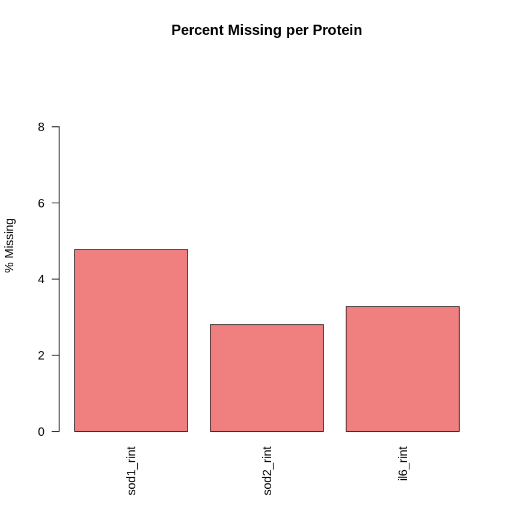

```r
# Check percentage of missing values for each protein
# Create a named vector of % missing
missing_pct <- colSums(is.na(prot[, protein_vars])) / nrow(prot) * 100

# Print rounded results
round(missing_pct, 2)

barplot(missing_pct,
        main = "Percent Missing per Protein",
        ylab = "% Missing",
        col = "lightcoral",
        ylim = c(0, max(missing_pct) + 5),
        las = 2)
```

Below 7% is normal.

A matrix: 3 × 3 of type dbl

|  | sod1_rint | sod2_rint | il6_rint |
| --- | --- | --- | --- |
| sod1_rint | 1.00 | 0.29 | 0.08 |
| sod2_rint | 0.29 | 1.00 | 0.08 |
| il6_rint | 0.08 | 0.08 | 1.00 |

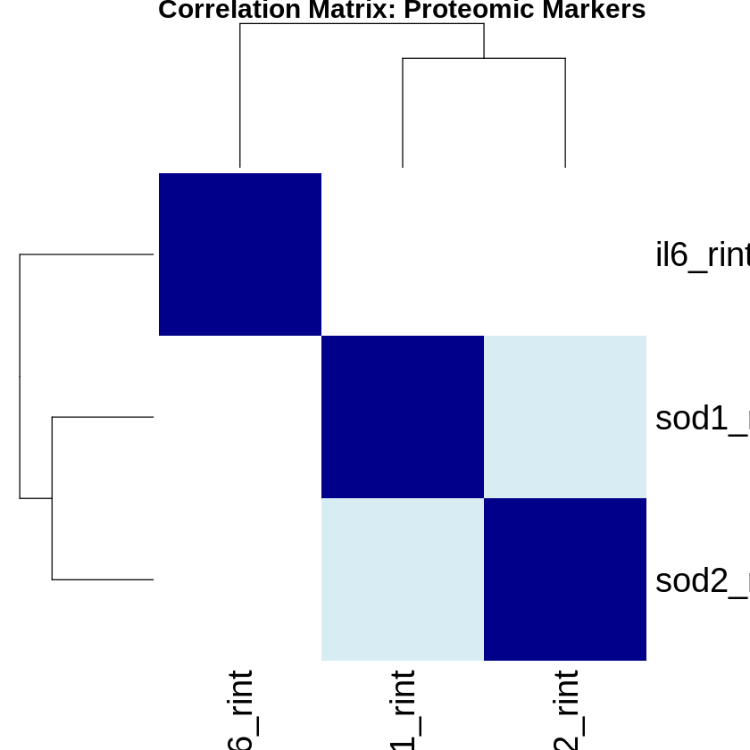

```r
# Create a correlation matrix
prot_subset <- prot[, protein_vars]

# Compute correlation matrix (pairwise complete)
cor_matrix_prot <- cor(prot_subset, use = "pairwise.complete.obs")

# Print matrix
round(cor_matrix_prot, 2)

# Heatmap
heatmap(cor_matrix_prot,
        main = "Correlation Matrix: Proteomic Markers",
        col = colorRampPalette(c("white", "lightblue", "darkblue"))(100),
        symm = TRUE)
```

SOD1 and SOD2 show weak-to-moderate correlation (r = 0.29) where they might show their relation to oxidative stress pathways. IL-6 shows minimal correlation with both SOD1 and SOD2. This shows that we have 3 distinct inflammation-related proteins.

```r
# Create a dataset with NA values removed
prot_no_na <- na.omit(prot)
write.csv(prot_no_na, "../notebooks/prot_no_na.csv", row.names = FALSE)
```

# Phenotype Data Exploration

```r
# Check % missing for key variables
core_vars <- c("disease", "age", "sex", "BMI", "waist_circumference", "tobacco_smoking")
missing_pct_pheno <- colSums(is.na(pheno[, core_vars])) / nrow(pheno) * 100
round(missing_pct_pheno, 2)
```

**disease**

0

**age**

0

**sex**

0

**BMI**

1.73

**waist_circumference**

0.39

**tobacco_smoking**

0

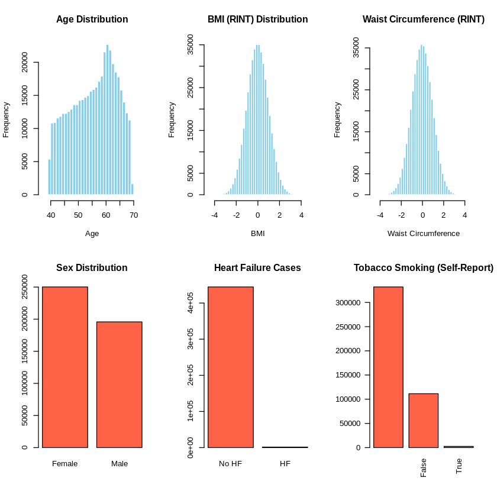

```r
# Core variables histograms of distribution
par(mfrow = c(2, 3))

# Numeric variables (continuous)
hist(pheno$age,
     main = "Age Distribution",
     xlab = "Age",
     col = "skyblue",
     border = "white",
     breaks = 40)

hist(pheno$BMI,
     main = "BMI (RINT) Distribution",
     xlab = "BMI",
     col = "skyblue",
     border = "white",
     breaks = 40)

hist(pheno$waist_circumference,
     main = "Waist Circumference (RINT)",
     xlab = "Waist Circumference",
     col = "skyblue",
     border = "white",
     breaks = 40)

# Categorical/binary variables as barplots
barplot(table(pheno$sex),
        main = "Sex Distribution",
        col = "tomato",
        names.arg = c("Female", "Male"))

barplot(table(pheno$disease),
        main = "Heart Failure Cases",
        col = "tomato",
        names.arg = c("No HF", "HF"))

barplot(table(pheno$tobacco_smoking),
        main = "Tobacco Smoking (Self-Report)",
        col = "tomato",
        las = 2)
```

A matrix: 4 × 4 of type dbl

|  | BMI | waist_circumference | weight | body_fat_percent |
| --- | --- | --- | --- | --- |
| BMI | 1.00 | 0.82 | 0.83 | 0.56 |
| waist_circumference | 0.82 | 1.00 | 0.88 | 0.24 |
| weight | 0.83 | 0.88 | 1.00 | 0.20 |
| body_fat_percent | 0.56 | 0.24 | 0.20 | 1.00 |

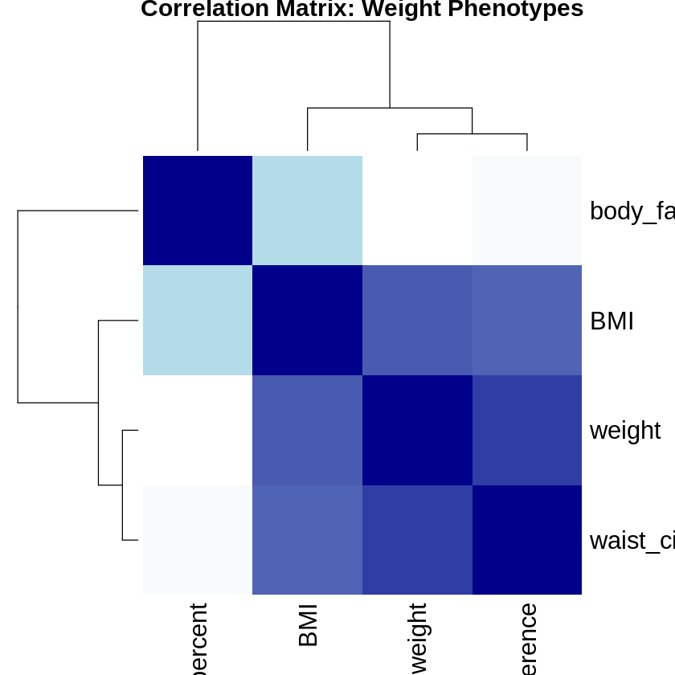

```r
# Correlation matric for weight-related phenotypes

# Select only weight-related variables from pheno
weight_vars <- c("BMI", "waist_circumference", "weight", "body_fat_percent")
pheno_weight <- pheno[, weight_vars]

# Compute correlation matrix (exclude NAs pairwise)
cor_matrix <- cor(pheno_weight, use = "pairwise.complete.obs")

# Print matrix values
round(cor_matrix, 2)

# Plot heatmap
heatmap(cor_matrix,
        main = "Correlation Matrix: Weight Phenotypes",
        col = colorRampPalette(c("white", "lightblue", "darkblue"))(100),
        symm = TRUE)
```

BMI, weight, and waist circumference are all strongly correlated. Body fat percent is less correlated with the others and may capture different information. I’ll avoid using highly correlated variables together in the same model. I also think that I can safely remove 'weight' from my dataset.

# Normalize Environmental Data

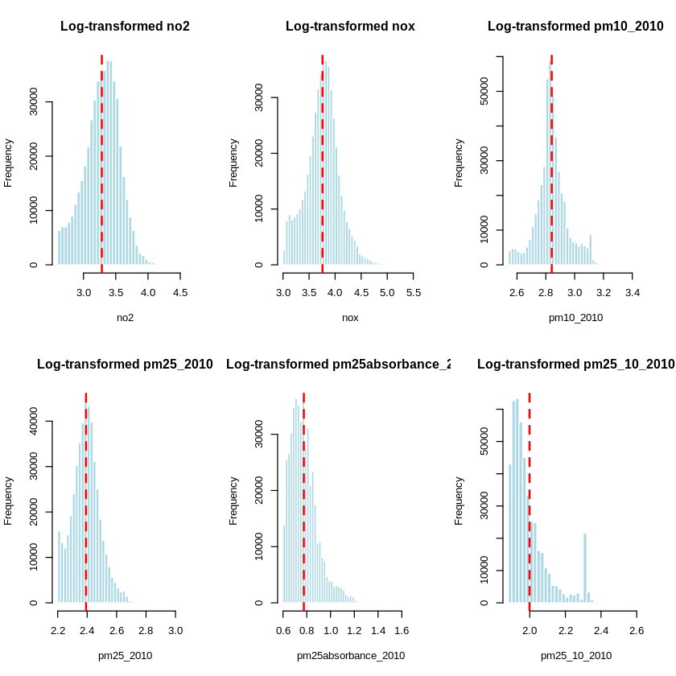

```r
# Apply log-transformation
# Create a new dataframe for log-transformed values
env_log <- env_clean

# Do transformation and add 1 to avoid issues with zeros before applying log
env_log[pollution_vars] <- log(env_clean[pollution_vars] + 1)

# Plot histograms to see if transformation worked
par(mfrow = c(2, 3))

# Loop through and plot each variable
for (var in pollution_vars) {
  hist(env_log[[var]],
       main = paste("Log-transformed", var),
       xlab = var,
       col = "lightblue",
       border = "white",
       breaks = 40)
  abline(v = mean(env_log[[var]], na.rm = TRUE), col = "red", lwd = 2, lty = 2)
}
```

This looks better but I am a little concerned with my PM absorbance distributions. Especially the pm 2.5 - 10 where it seems like there is a group of outliers. I'm going to examine these variables after transformation to see if I need to trim outliers.

```r
summary(env_clean$pm25absorbance_2010)
summary(env_log$pm25absorbance_2010)
```

```
   Min. 1st Qu.  Median    Mean 3rd Qu.    Max.    NA's
   0.83    1.00    1.13    1.19    1.30    4.60   33916
```

```
   Min. 1st Qu.  Median    Mean 3rd Qu.    Max.    NA's
   0.60    0.69    0.76    0.78    0.83    1.72   33916
```

[output not shown]

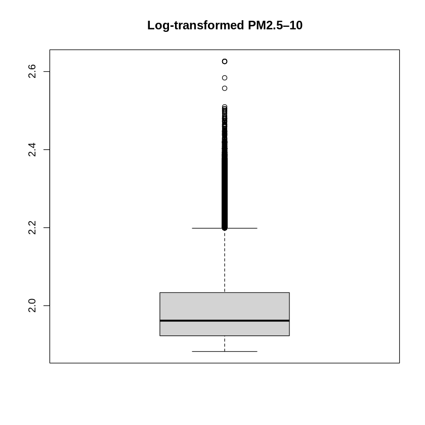

```r
boxplot(env_log$pm25_10_2010, main = "Log-transformed PM2.5–10")
summary(env_log$pm25_10_2010)
```

Even though this data still shows skew and some outliers I don't want to take these cases out quite yet since these could be real values that might be important for our analysis. Robust models (like logistic regression) should also be able to work with these datapoints.

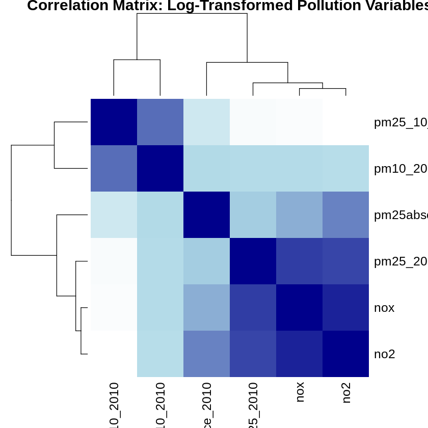

```r
# Create a correlation matrix for log-transformed environmental variables
# Subset the log-transformed environmental data
env_pollution <- env_log[ , pollution_vars]

# Compute correlation matrix
cor_matrix_env <- cor(env_pollution, use = "pairwise.complete.obs")

# Plot heatmap
heatmap(cor_matrix_env,
        main = "Correlation Matrix: Log-Transformed Pollution Variables",
        col = colorRampPalette(c("white", "lightblue", "darkblue"))(100),
        symm = TRUE)
```

```r
# Save normalized environmental dataset as CSV
write.csv(env_log, "../notebooks/env_clean.csv", row.names = FALSE)

# Create another dataset eliminating NA values
env_no_na <- na.omit(env_clean)
write.csv(env_no_na, "../notebooks/env_no_na.csv", row.names = FALSE)
```

# Prep and trim Phenotype Data

```r
# Core variables
core_vars <- c("participant_id", "disease", "age", "sex",
               "BMI", "waist_circumference", "body_fat_percent")

# Create the cleaned phenotype dataset
pheno_clean <- pheno[ , core_vars]
```

**participant_id**

0

**disease**

0

**age**

1

**sex**

1

**BMI**

7729

**waist_circumference**

1730

**body_fat_percent**

7949

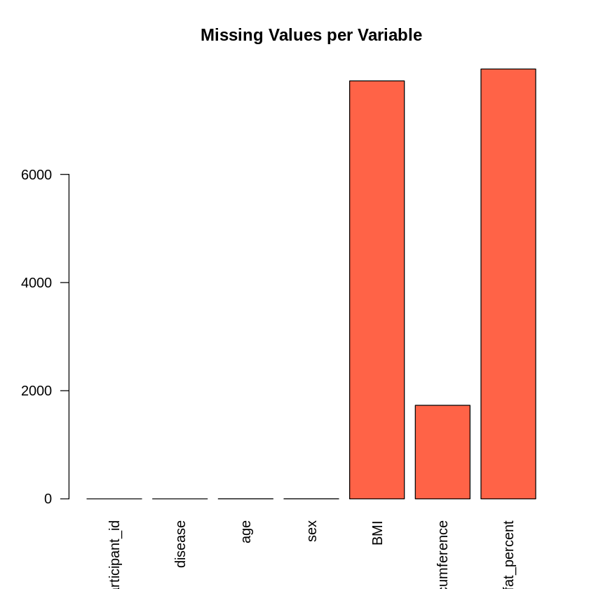

```r
# Check NA values
colSums(is.na(pheno_clean))

barplot(colSums(is.na(pheno_clean)),
        main = "Missing Values per Variable",
        col = "tomato",
        las = 2)
```

There are over 7,000 missing datapoints (likely for the same participants) for measurements pertaining to weight. I think I am going to just keep the dataset as is until I figure out what we want from each analysis.

A matrix: 6 × 6 of type dbl

|  | disease | age | sex | BMI | waist_circumference | body_fat_percent |
| --- | --- | --- | --- | --- | --- | --- |
| disease | 1.00 | 0.03 | 0.03 | 0.03 | 0.04 | 0.00 |
| age | 0.03 | 1.00 | 0.00 | 0.05 | 0.09 | 0.12 |
| sex | 0.03 | 0.00 | 1.00 | 0.11 | 0.46 | -0.65 |
| BMI | 0.03 | 0.05 | 0.11 | 1.00 | 0.82 | 0.56 |
| waist_circumference | 0.04 | 0.09 | 0.46 | 0.82 | 1.00 | 0.24 |
| body_fat_percent | 0.00 | 0.12 | -0.65 | 0.56 | 0.24 | 1.00 |

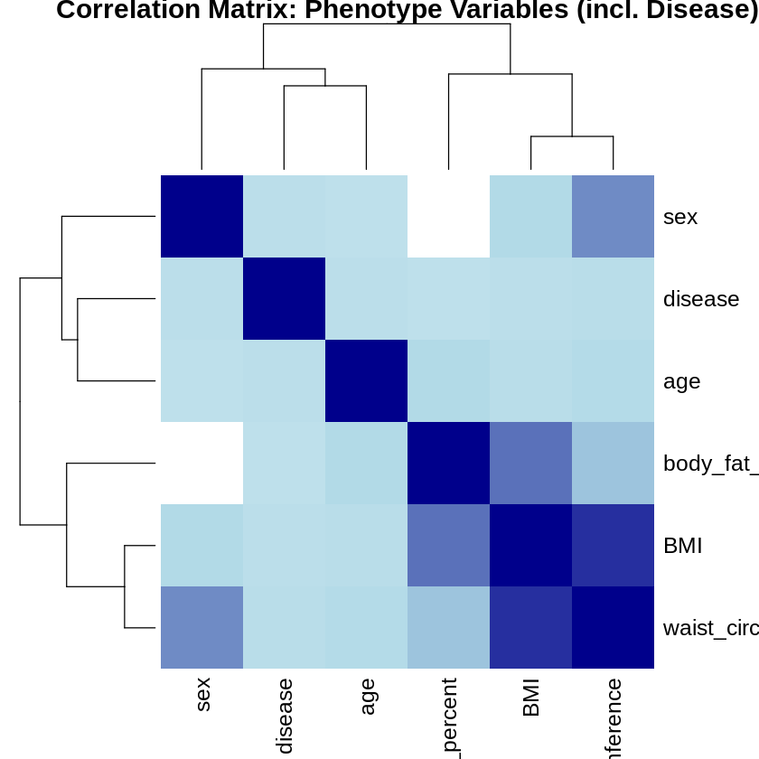

```r
# Correlation matrix for all numeric phenotype variables

# Manually select columns, including disease
pheno_corr <- pheno_clean[, c("disease", "age", "sex",
                               "BMI", "waist_circumference",
                               "body_fat_percent")]

# Compute correlation matrix
cor_matrix_pheno <- cor(pheno_corr, use = "pairwise.complete.obs")

# Visualize
heatmap(cor_matrix_pheno,
        main = "Correlation Matrix: Phenotype Variables (incl. Disease)",
        col = colorRampPalette(c("white", "lightblue", "darkblue"))(100),
        symm = TRUE)

# Print matrix
round(cor_matrix_pheno, 2)

### Most phenotype variables show weak correlations with disease status, which is expected due to low prevalence.
```

```r
# Save cleaned phenotype dataset as CSV
write.csv(pheno_clean, "../notebooks/pheno_clean.csv", row.names = FALSE)

# Create another dataset without NA values
pheno_no_na <- na.omit(pheno_clean)
write.csv(pheno_no_na, "../notebooks/pheno_no_na.csv", row.names = FALSE)
```

# Plot overlaps between Participant IDs

```r
# Get participant IDs from each dataset
pheno_ids <- pheno_clean$participant_id
pollution_ids <- env_clean$participant_id
prot_ids <- prot$participant_id

# Count overlaps
length(intersect(pheno_ids, pollution_ids))  # pheno + pollution
length(intersect(pheno_ids, prot_ids))   # pheno + proteomics
length(Reduce(intersect, list(pheno_ids, pollution_ids, prot_ids)))  # all three
```

439509

45920

45260

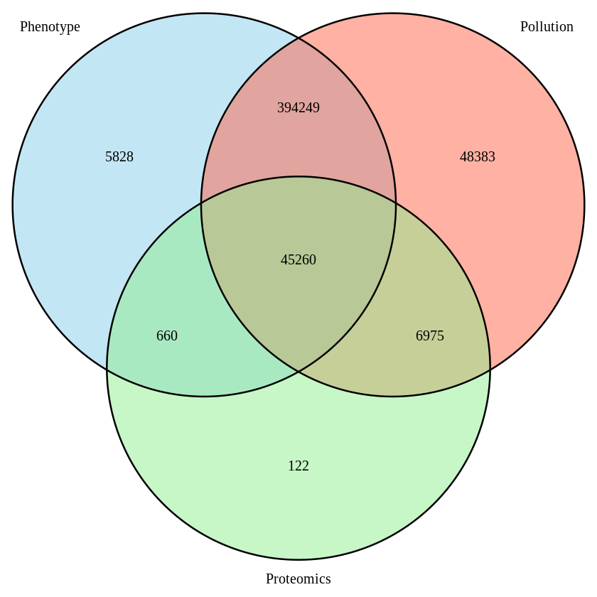

```r
install.packages("VennDiagram")

library(VennDiagram)

venn <- venn.plot <- draw.triple.venn(
  area1 = length(pheno_ids),
  area2 = length(pollution_ids),
  area3 = length(prot_ids),
  n12 = length(intersect(pheno_ids, pollution_ids)),
  n23 = length(intersect(pollution_ids, prot_ids)),
  n13 = length(intersect(pheno_ids, prot_ids)),
  n123 = length(Reduce(intersect, list(pheno_ids, pollution_ids, prot_ids))),
  category = c("Phenotype", "Pollution", "Proteomics"),
  fill = c("skyblue", "tomato", "lightgreen")
)

ggsave(
  filename = "Figures/venn_dataset_size.png",
  plot = venn,
  width = 3,                     # 3 inches × 300 dpi = 900 pixels
  height = 3,
  dpi = 300
)
```

There's a good overlap between phenotype and polluion (as we anticipated) which will create a strong base for our primary analyses. That will be its own dataset.

Our second dataset will include all 3 datasets where the proteomics dataset will limit our overlapping participants to 45,260. We knew that we would have a significant decrease in participants but this will be the base for our sub-analysis focusing on answering our proteomics data.